# Part II 2019-Ford Go Bike Dataset Visualization

## by Suleiman Mohamed

## Investigation Overview

> My presentation's main purpose is to generate responses to the following questions:
> - What gender rides bikes the most?
> - Which time of day is the busiest?
> - Which user type rides the most bikes?
> - Which day of the week is the busiest?
> - How does the distribution of User type ride counts differ between age groups?

## Dataset Overview

> This data set includes information about individual rides made in a bike-sharing system covering the greater San Francisco Bay area.

## 1. What gender rides bikes the most?

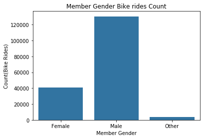

The graph above shows that `Males` ride bikes the most (over 120,000 counts), followed by `Females` (about 40,000 counts). `Others` received a count of fewer than 10,000.

## 2. Which time of day is the busiest?

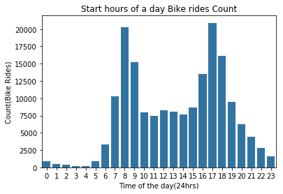

The graph above shows that it is mostly busy between 8 a.m. and 5 p.m. While the average is between 8 a.m. and 5 p.m., there is a decline after 5 p.m. until 4 a.m., when it begins to increase until 8 a.m.

## 3. Which user type rides the most bikes?

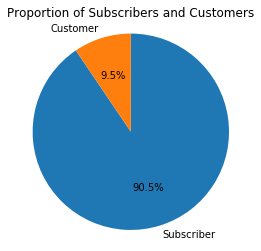

According to the graph above, subscribers ride 90.5% of the bikes compared to customers who ride 9.5% of the bikes.

## 4. Which day of the week is the busiest?

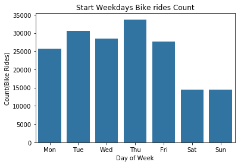

The graph above shows that Thursday is the busiest day. The number of rides on weekdays exceeds 25,000, which is higher than the number of rides on weekends, which is constant around 15,000 in number.

## 5. How does the distribution of User type ride counts differ between age groups?

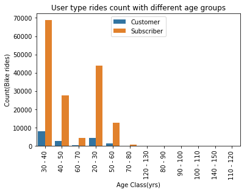

The graph above illustrates that the age group 30-40yrs has more user types than the other age groups. The age group 60-70 has the fewest customers, while the age group 70-80 has the fewest subscribers. There are no user types for the age groups 80-90, 90-100, 100-110, 110-120, 120-130, and 140-150. There are no customers between the ages of 70 and 80.